# RDA for Sound analysis

В. М. Хайтов

2023-07-19

```r
library(readxl)
library(vegan)
library(dplyr)
```

Файл BD.csv я преобразовал в экселевский файл. При этом ввел более дробное разбинние времени суток на несколько категорий (Morning, Day, Evening, Nigth).

```r
dat <- read_excel("Short_observation.xlsx")

sound <- dat %>% select(Ins, Anur, Bird, Mam, Wind, Rain, Noise)

sound_perc <- decostand(x = sound, MARGIN = 1, method = "total") #Выражаем в представленность источников звука в долях.

predictors <- dat %>% select(Indx, Month_, Day_Part_)
```

Вот модель для Redundancy Analysis (RDA). Это такая форма многомерного анализа, в которой сочетается метод главных компонент (PCA) и линейные модели.

```r
Mod <- rda(sound ~ Month_ + Day_Part_, data = predictors)
```

Вот summary от этой модели.

```r
summary(Mod)
```

```
##
## Call:
## rda(formula = sound ~ Month_ + Day_Part_, data = predictors)
##
## Partitioning of variance:
##               Inertia Proportion
## Total           466.6     1.0000
## Constrained     177.9     0.3813
## Unconstrained   288.7     0.6187
##
## Eigenvalues, and their contribution to the variance
##
## Importance of components:
##                          RDA1    RDA2     RDA3    RDA4     RDA5     RDA6
## Eigenvalue            91.0886 49.4102 22.55335 8.89824 4.090246 1.301192
## Proportion Explained   0.1952  0.1059  0.04833 0.01907 0.008766 0.002789
## Cumulative Proportion  0.1952  0.3011  0.34943 0.36850 0.377269 0.380058
##                           RDA7      PC1     PC2      PC3     PC4      PC5
## Eigenvalue            0.578229 127.8084 69.3562 39.48784 22.1663 18.78496
## Proportion Explained  0.001239   0.2739  0.1486  0.08463  0.0475  0.04026
## Cumulative Proportion 0.381297   0.6552  0.8038  0.88846  0.9360  0.97622
##                           PC6     PC7
## Eigenvalue            6.28386 4.81075
## Proportion Explained  0.01347 0.01031
## Cumulative Proportion 0.98969 1.00000
##
## Accumulated constrained eigenvalues
## Importance of components:
##                         RDA1    RDA2    RDA3    RDA4    RDA5     RDA6    RDA7
## Eigenvalue            91.089 49.4102 22.5534 8.89824 4.09025 1.301192 0.57823
## Proportion Explained   0.512  0.2777  0.1268 0.05001 0.02299 0.007313 0.00325
## Cumulative Proportion  0.512  0.7897  0.9164 0.96645 0.98944 0.996750 1.00000
##
## Scaling 2 for species and site scores
## * Species are scaled proportional to eigenvalues
## * Sites are unscaled: weighted dispersion equal on all dimensions
## * General scaling constant of scores:  14.66052
##
##
## Species scores
```

[output cut: 244 more lines]

```
## Month_Aug        -1.4477  0.692714 -1.0727 -1.77521  0.61202 -1.43056
## Month_Dec         1.1101 -1.384553  0.9309  0.05235 -0.02294 -0.01724
## Month_Feb        -1.0870  0.006632 -0.9057 -1.48985  0.45016 -1.01744
## Month_Jan         1.7063  0.366803  0.5432 -0.18526  0.59621 -0.05903
## Month_Jul         0.5871 -1.781779 -3.9958  7.88897 -0.04369 -2.85546
## Month_Jun        -1.5509  0.337342 -0.7022 -1.90030  1.16132 -1.61979
## Month_Mar         0.2173  0.713805 -0.7661  0.64513 -0.65996  3.35187
## Month_May        -2.0097 -0.322882  0.2688  1.51360  1.85968  0.80544
## Month_Nov         2.7242 -4.579021 -2.1431 -1.48121 -5.96853 -1.08573
## Month_Oct        -1.5304  0.791933  1.5568  0.53979 -3.15551 -0.48948
## Month_Sep         0.5713  0.996611 -2.2826 -0.86612 -0.38879 -0.98560
## Day_Part_Day     -0.0262 -0.889220 -0.8515 -0.16315 -0.25130 -0.15766
## Day_Part_Evening -0.9000  1.247815 -1.0862 -0.25016 -0.15735  1.94310
## Day_Part_Morning -0.5681 -1.745864  0.5072 -0.41682  0.12561  0.04352
## Day_Part_Night    0.5588  1.099625  0.7022  0.39132  0.16973 -0.48930
```

Ниже приводятся результаты пермутационной оценки значимости самой модели, ее канонических осей и предикторов, включенных в модель.

```r
anova(Mod)
```

```
## Permutation test for rda under reduced model
## Permutation: free
## Number of permutations: 999
##
## Model: rda(formula = sound ~ Month_ + Day_Part_, data = predictors)
##          Df Variance      F Pr(>F)
## Model    14   177.92 3.7417  0.001 ***
## Residual 85   288.70
## ---
## Signif. codes:  0 '***' 0.001 '**' 0.01 '*' 0.05 '.' 0.1 ' ' 1
```

```r
anova(Mod, by = "axis")
```

```
## Permutation test for rda under reduced model
## Forward tests for axes
## Permutation: free
## Number of permutations: 999
##
## Model: rda(formula = sound ~ Month_ + Day_Part_, data = predictors)
##          Df Variance       F Pr(>F)
## RDA1      1   91.089 29.0274  0.001 ***
## RDA2      1   49.410 15.7456  0.001 ***
## RDA3      1   22.553  7.1871  0.305
## RDA4      1    8.898  2.8356  0.987
## RDA5      1    4.090  1.3034  1.000
## RDA6      1    1.301  0.4147  1.000
## RDA7      1    0.578  0.1843  1.000
## Residual 92  288.698
## ---
## Signif. codes:  0 '***' 0.001 '**' 0.01 '*' 0.05 '.' 0.1 ' ' 1
```

```r
anova(Mod, by = "margin")
```

```
## Permutation test for rda under reduced model
## Marginal effects of terms
## Permutation: free
## Number of permutations: 999
##
## Model: rda(formula = sound ~ Month_ + Day_Part_, data = predictors)
##           Df Variance      F Pr(>F)
## Month_    11  124.633 3.3359  0.001 ***
## Day_Part_  3   40.047 3.9303  0.001 ***
## Residual  85  288.698
## ---
## Signif. codes:  0 '***' 0.001 '**' 0.01 '*' 0.05 '.' 0.1 ' ' 1
```

Теперь визуализация модели.

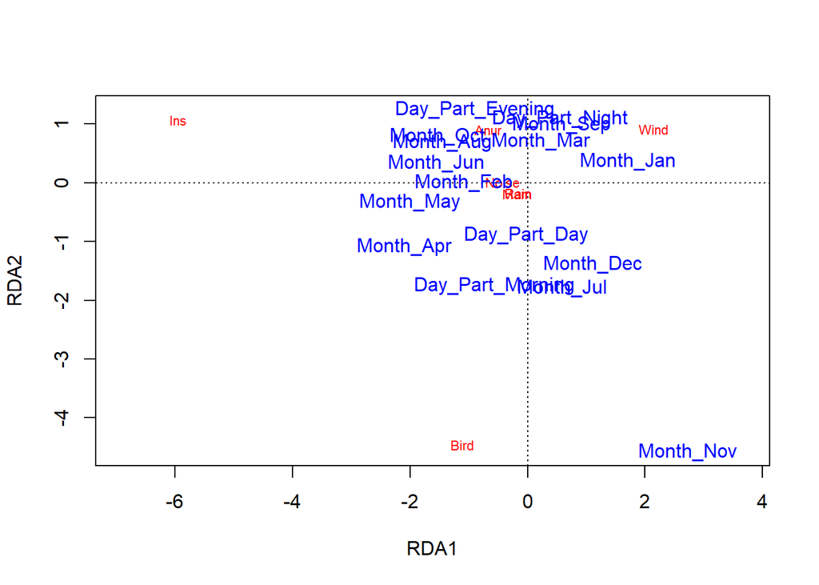

```r
plot(Mod, display = c("species", "cn"), scaling = "species")
```

Картинка вполне трактуемая.

1. Есть два относительно независимых комплекса источников звуков. Первый это Ins VS Wind (они связаны с первой канонической осью). При этом эта картинка говорит о том, что чем больше ветра, тем меньше насекомых (и наоборот). Второй - это Anur VS Bird (они связаны со второй канонической осью). Чем меньше Bird, тем больше Anur (и наоборот).
2. Первая ось, которая насекомые vs ветер, хорошо коррелирует с месяцами. Ветра много в Jan, насекомых много в Jun, Aug, Oct.
3. Насекомые слабо связаны со временем суток (об этом говорит, что центроиды для разных времен дня вытянуты вдоль второй канонической оси, а насекомые имеют большие нагрузки по первой оси). Хотя их чуть больше к вечеру.
4. Вторая каноническая ось хорошо коррелирует со временем суток. При этом птицы более обильны утром и днем, а лягушки - вечером и ночью.
5. Включенные в модель предикторы не влияют на представленность в “сообществе” млекопитающих, шума и дождя. Эти элементы концентрируются в районе нулей по обеим каноническим осям.

Итого, структура “сообщества” звуков имеет и годовую, и суточную динамику. Зимой много ветра, но мало насекомых. Летом много насекомых и мало ветра. Лягушки и птицы меньше зависят от времени года (хотя некоторая связь есть), но делят сутки (первых больше к вечеру и в ночи, вторых - утром и днем )

Посмотрите результаты и пройдитесь по коду (картинку лучше смотреть при большем увеличении). Для справки про то, что такое RDA кидаю свою презентацию для курса, который я веду для СПбГУ.